# Regularización: Lasso, Ridge y Elastic Net

Juan Manuel Barriola, Azul Villanueva y Franco Mastelli

29 de Octubre de 2022

```r
library(tidyverse)
library(tidymodels)
library(GGally)
library(cowplot)
library(glmnet)
library(RColorBrewer)
set.seed(2022)
```

# Planteo del Problema

El problema que vamos a tratar de resolver es **predecir** el **salario** de un **jugador de la NBA** para la temporada 2022-2023 en base a sus estadísticas de juego durante la temporada 2021-2022.

Las técnicas de **regularización** son útiles para trabajar con conjuntos con **gran cantidad de variables**, las cuales pueden introducir variabilidad en las estimaciones de los parámetros.

## Conjuntos de datos

Los datos provienen de la página [Basketball Reference](https://www.basketball-reference.com) y fueron previamente trabajados por nosotros para obtener el formato actual.

Las variables del set son:

```r
diccionario = read_csv("diccionario_terminos.csv")
diccionario
```

| variable | descripcion |
| --- | --- |
| Player | nombre |
| Pos | Posición |
| Age | Edad |
| G | Partidos |
| GS | Partidos que comenzó como titular |
| MP | Minutos jugados |
| PTS | Points |
| FG | Field Goals |
| FGA | Field Goal Attempts |
| FG% | Field Goal Percentage |

[output cut: 38 more lines]

En el glosario de [Basketball Reference](https://www.basketball-reference.com/about/glossary.html) pueden encontrar una descripción más exhaustiva de cada una de estas métricas.

```r
# Los datos de salario son para la temporada 2022-2023
nba = read_csv("../fuentes/nba/nba_player_stats_salary_2022_2023.csv") %>%
  mutate(Pos = str_remove(string = Pos, pattern = "\\-.*")) %>%
  mutate_all(~replace(., is.na(.), 0))

glimpse(nba)
```

```
## Rows: 404
## Columns: 50
## $ jugador <chr> "Precious Achiuwa", "Steven Adams", "Bam Adebayo", "Santi Alda~
## $ Pos     <chr> "C", "C", "C", "PF", "SG", "SG", "C", "PG", "PF", "PF", "SF", ~
## $ Age     <dbl> 22, 28, 24, 21, 23, 26, 23, 23, 28, 27, 29, 21, 24, 34, 21, 23~
## $ Tm      <chr> "TOR", "MEM", "MIA", "MEM", "TOT", "MIL", "CLE", "NOP", "MEM",~
## $ G       <dbl> 73, 76, 56, 32, 65, 66, 56, 54, 69, 67, 48, 65, 48, 55, 82, 58~
## $ GS      <dbl> 28, 75, 56, 0, 21, 61, 56, 1, 11, 67, 6, 65, 48, 2, 8, 58, 6, ~
## $ MP      <dbl> 1725, 1999, 1825, 360, 1466, 1805, 1809, 834, 1484, 2204, 473,~
## $ FG      <dbl> 265, 210, 406, 53, 253, 255, 369, 131, 209, 689, 70, 357, 309,~
## $ FGA     <dbl> 603, 384, 729, 132, 680, 569, 545, 294, 469, 1245, 128, 912, 6~
## $ `FG%`   <dbl> 0.439, 0.547, 0.557, 0.402, 0.372, 0.448, 0.677, 0.446, 0.446,~
## $ `3P`    <dbl> 56, 0, 0, 6, 105, 159, 1, 32, 36, 71, 2, 132, 115, 68, 82, 7, ~
## $ `3PA`   <dbl> 156, 1, 6, 48, 338, 389, 10, 110, 109, 242, 14, 391, 317, 164,~
## $ `3P%`   <dbl> 0.359, 0.000, 0.000, 0.125, 0.311, 0.409, 0.100, 0.291, 0.330,~
```

[output cut: 37 more lines]

Existen 404 observaciones y 50 variables en el dataset.

## Análisis Exploratorio

### Gráfico de la relación entre la posición y el salario

Veamos como es la distribución de salarios según la posición en el juego. Se agregan las etiquetas de los jugadores que cobran mayores sueldos.

Para contextualizar, en el basket 5 posiciones:

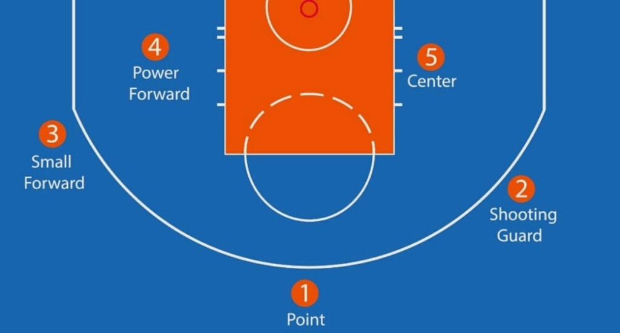

Fuente: www.chaseyoursport.com

- **Point Guard (PG)**: conocido como base, se caracteriza por su habilidad para pasar y manejar la pelota y organizar las jugadas. Suelen ser personas de baja estatura en el equipo.
- **Shooting Guard (SG)**: conocido como escolta, se caracteriza por su habilidad para anotar de larga y media distancia. También suelen tener buenas habilidades de manejo y pase de la pelota.
- **Small Forward (SF)**: conocido como alero, se la considera la posición más versátil de todas. Se caracterizan por su capacidad de anotar puntos de maneras distintas (triples, tiros a distancia media y corta) y su capacidad atlética.
- **Power Forward (PF)**: conocido como ala pivot, se caracteriza por anotar desde un rango medio a corto y la defensa próxima al aro. Suelen ser jugadores altos pero con mayor flexibilidad que los pivots.
- **Center (C)**: conocido como pivot, se caracteriza por ser jugadores muy altos y jugar cerca del aro, motivo por el cual se destacan en en las anotaciones de 2 puntos, la toma de rebotes y bloqueos.

```r
top_player_by_pos = nba %>%
  group_by(Pos) %>%
  filter(salario == max(salario)) %>%
  ungroup() %>%
  select(jugador) %>%
  pull()

print(top_player_by_pos)
```

```
## [1] "Bradley Beal"    "Stephen Curry"   "Rudy Gobert"     "LeBron James"
## [5] "Khris Middleton"
```

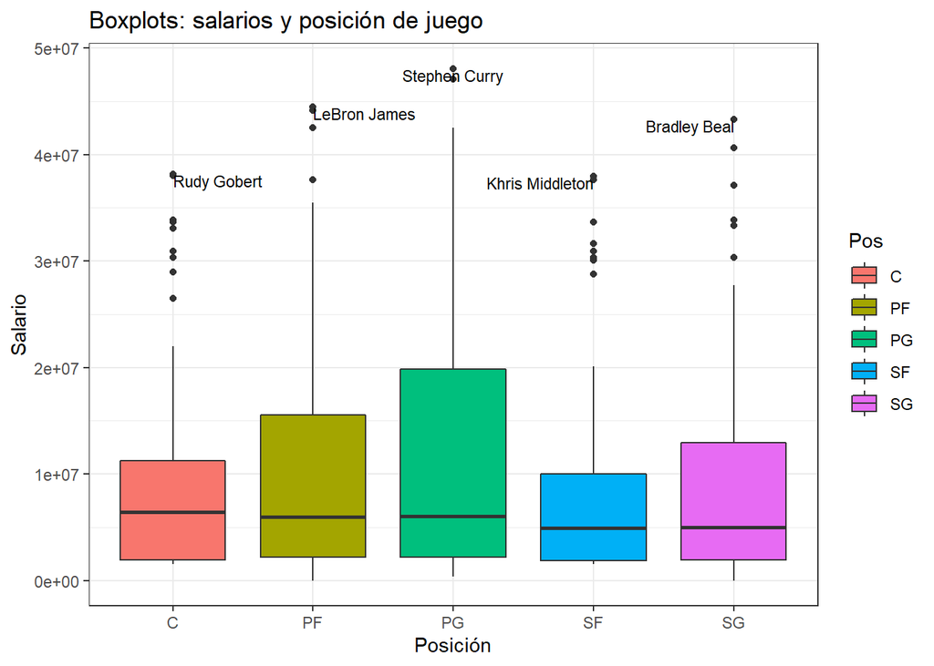

```r
ggplot(nba, aes(Pos, salario, fill=Pos)) +
  geom_boxplot() +
  geom_text(aes(label=ifelse((salario>30500000) & jugador %in% top_player_by_pos,as.character(jugador),'')),vjust="inward",hjust="inward", size=3) +
  theme_bw() +
  labs(title= "Boxplots: salarios y posición de juego", x="Posición", y="Salario")
```

Observamos que la distribución varía un poco entre posiciones y hay varios jugadores que son outliers según el criterio de Tukey.

## Correlograma

Realizamos un correlograma entre todas las variables cuantitativas.

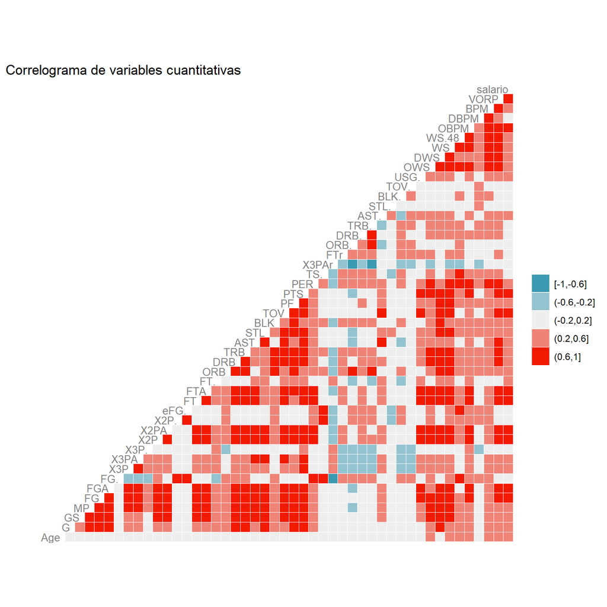

```r
nba %>%
  select_if(is.numeric) %>% # selección variables numéricas
  ggcorr(., layout.exp = 5, hjust = 1, size = 3.5, nbreaks = 5, color = "grey50") + # graficamos correlacion pearson
  labs(title='Correlograma de variables cuantitativas')
```

Observamos que existen relaciones de diversa magnitud y signo entre todas las variables.

## GGpairs (algunas variables)

Seleccionamos algunas variables y vemos sus relaciones usando `ggpairs`.

¿Cómo es la relación del salario con las demás variables?

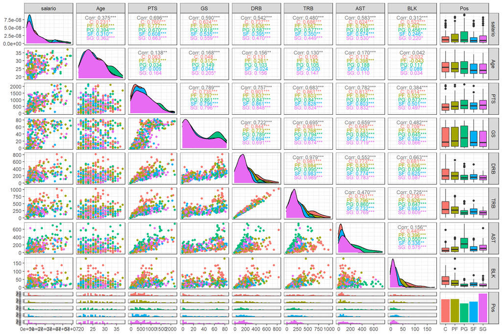

```r
nba %>%
  select(salario, Age, PTS, GS, DRB, TRB, AST, BLK, Pos) %>%
  ggpairs(aes(color = Pos), upper = list(continuous = wrap("cor", size = 3, hjust=0.5)), progress=FALSE) +
  theme(axis.text.x = element_text(angle = 90, hjust = 1), legend.position = "bottom") +
  theme_bw()
```

Observamos que la correlación de todas estas variables con el **salario** es **positiva** pero de diversa magnitud.

También se ve que existen correlaciones muy fuertes entre ciertas variables. Por ejemplo, entre **TRB** (Total de Rebotes) y **DRB** (Rebotes Defensivos).

# Modelo Lineal

Vamos a probar un modelo lineal que incluya todas las variables (excepto al jugador y equipo) y obtener las estimaciones de los parámetros junto a su p-valor e intervalo de confianza.

## Coeficientes estimados

Creamos el modelo y accedemos a información de los coeficientes e intervalos usando tidy.

```r
# Eliminamos jugador y equipo
nba = nba %>% select(-c(jugador, Tm))
# Modelo lineal
modelo_lineal = nba %>% lm(formula = salario~., data = .)
#Coeficientes
lineal_coef = modelo_lineal %>% tidy(conf.int=TRUE)
```

Graficamos los coeficientes estimados.

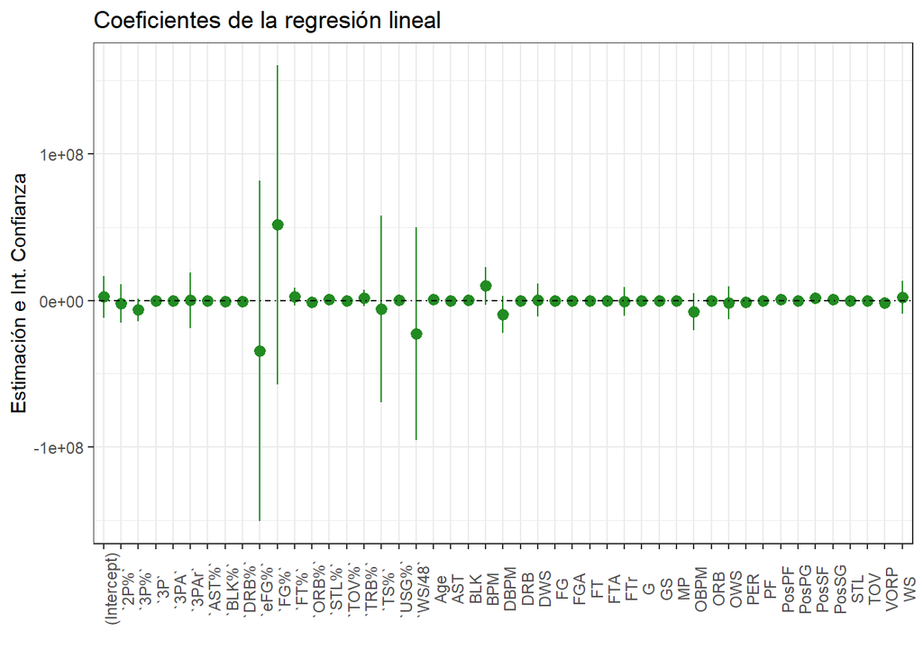

```r
lineal_coef %>% filter(!is.na(estimate)) %>%
  ggplot(., aes(term, estimate))+
  geom_point(color = "forestgreen")+
  geom_pointrange(aes(ymin = conf.low, ymax = conf.high), color = "forestgreen")+
  geom_hline(yintercept = 0, lty = 4, color = "black") +
  labs(title = "Coeficientes de la regresión lineal", x="", y="Estimación e Int. Confianza") +
  theme_bw() +
  theme(axis.text.x = element_text(angle=90))
```

Graficamos los p-valores de mayor a menor para evaluar la significatividad individual de los coeficientes estimados.

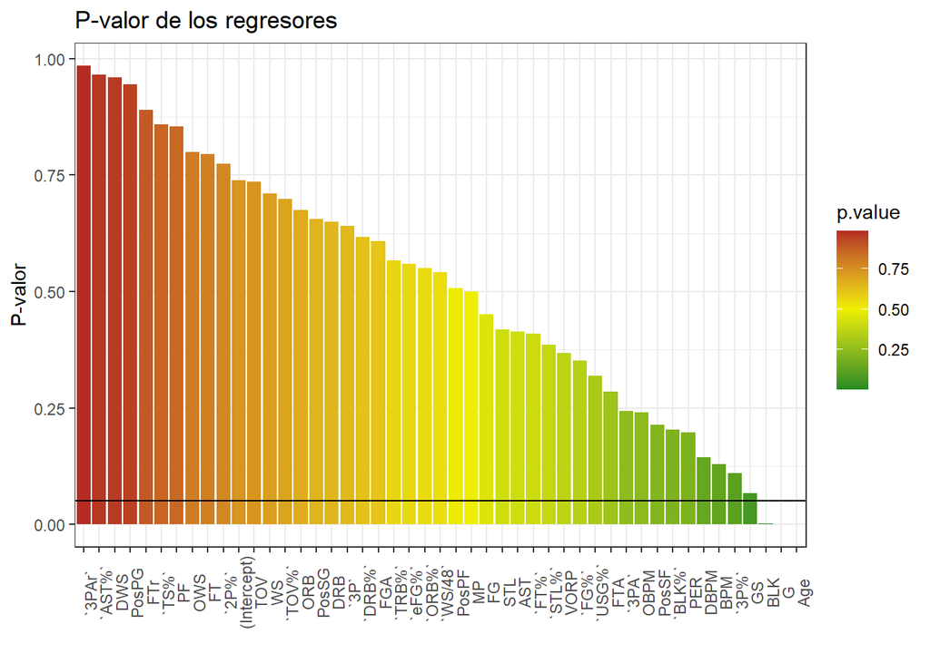

```r
lineal_coef %>% filter(!is.na(estimate)) %>%
  ggplot(., aes(reorder(term, -p.value), p.value, fill=p.value))+
  geom_bar(stat = 'identity', aes(fill=p.value))+
  geom_hline(yintercept = 0.05) +
  labs(title = "P-valor de los regresores", x="", y="P-valor") +
  theme_bw() +
  theme(axis.text.x = element_text(angle=90)) +
  scale_fill_gradient2(high='firebrick', low = 'forestgreen', mid='yellow2',midpoint = 0.5 )
```

Notamos que:

- Hay ciertos coeficientes estimados que presentan una gran variabilidad pero la escala de las variables puede ocultarnos la verdadera variabilidad de los estimadores.
- Pocas variables tienen coeficientes significativos: **BLK**, **G** y **Age**.
- Existen cuatro variables cuyo coeficiente estimado es NA: **2P**, **2PA**, **PTS** y **TRB**.

```r
lineal_coef %>% filter(is.na(estimate))
```

| term | estimate | std.error | statistic | p.value | conf.low | conf.high |
| --- | --- | --- | --- | --- | --- | --- |
| `2P` | NA | NA | NA | NA | NA | NA |
| `2PA` | NA | NA | NA | NA | NA | NA |
| TRB | NA | NA | NA | NA | NA | NA |
| PTS | NA | NA | NA | NA | NA | NA |

Cuando una variable se puede expresar como una combinación lineal de otra, el modelo lineal de R devuelve los valores de los coeficientes estimados como *NA*.

Para evitar los problemas que puede introducir la escala, reescalamos las variables con el comando `scale` y repetimos el ajuste para estos nuevos datos.

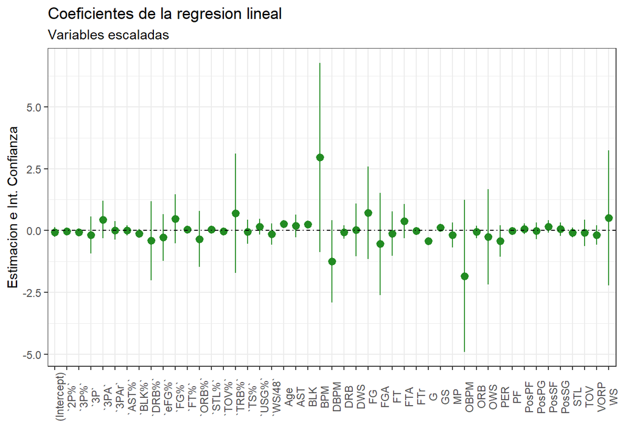

```r
# Reescalamos las variables numericas
nba_scaled = nba %>% mutate_at(vars(-Pos), scale)
# Nuevo modelo lineal
modelo_lineal_scal = nba_scaled %>% lm(formula = salario~., data = .)
lineal_coef_scal = modelo_lineal_scal %>% tidy(conf.int=TRUE)

lineal_coef_scal %>% filter(!is.na(estimate)) %>%
  ggplot(., aes(term, estimate))+
  geom_point()+
  geom_pointrange(aes(ymin = conf.low, ymax = conf.high), color = "forestgreen")+
  geom_hline(yintercept = 0, lty = 4, color = "black") +
  labs(title = "Coeficientes de la regresion lineal", subtitle="Variables escaladas", x="", y="Estimacion e Int. Confianza") +
  theme_bw() +
  theme(axis.text.x = element_text(angle=90))
```

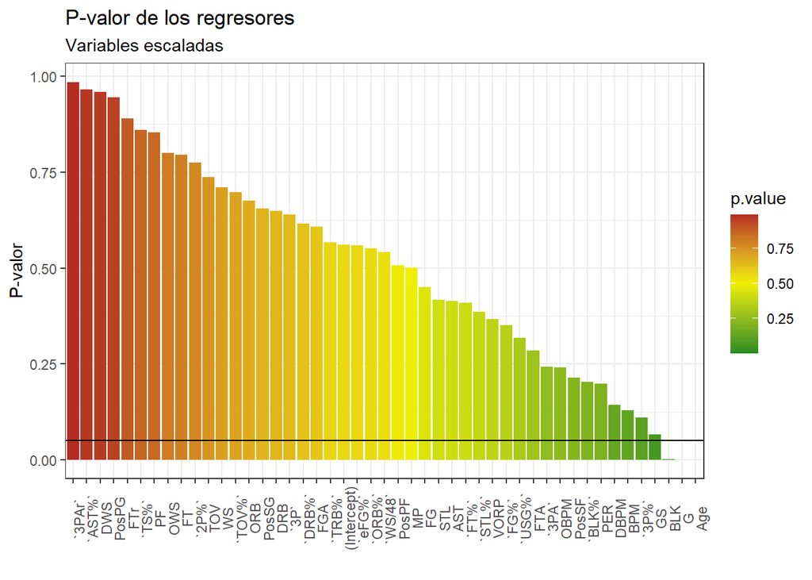

```r
lineal_coef_scal %>% filter(!is.na(estimate)) %>%
  ggplot(., aes(reorder(term, -p.value), p.value, fill=p.value))+
  geom_bar(stat = 'identity', aes(fill=p.value))+
  geom_hline(yintercept = 0.05) +
  labs(title = "P-valor de los regresores",subtitle="Variables escaladas", x="", y="P-valor") +
  theme_bw() +
  theme(axis.text.x = element_text(angle=90)) +
  scale_fill_gradient2(high='firebrick', low = 'forestgreen', mid='yellow2',midpoint = 0.5 )
```

Ahora observamos que:

- Los coeficientes cambian de valor.
- Las mismas tres variables tienen coeficientes significativos: **BLK**, **G** y **Age**.
- Las mismas cuatro variables tienen coeficiente estimado NA: **2P**, **2PA**, **PTS** y **TRB**.

```r
lineal_coef_scal %>% filter(is.na(estimate))
```

| term | estimate | std.error | statistic | p.value | conf.low | conf.high |
| --- | --- | --- | --- | --- | --- | --- |
| `2P` | NA | NA | NA | NA | NA | NA |
| `2PA` | NA | NA | NA | NA | NA | NA |
| TRB | NA | NA | NA | NA | NA | NA |
| PTS | NA | NA | NA | NA | NA | NA |

## Evaluación de los modelos

Obtemos la evaluación de ambos modelos ¿Cómo esperan que sean los valores de las métricas de performance?

```r
modelos_lineales = list(lineal = modelo_lineal, lineal_escalado = modelo_lineal_scal)
map_dfr(.x = modelos_lineales, .f = glance, .id="modelo") %>%
  select(modelo, r.squared, adj.r.squared, p.value)
```

| modelo | r.squared | adj.r.squared | p.value |
| --- | --- | --- | --- |
| lineal | 0.7371808 | 0.7033161 | 3.901733e-78 |
| lineal_escalado | 0.7371808 | 0.7033161 | 3.901733e-78 |

La alta cantidad de variables y la existencia de una alta correlación entre varias de ellas ocasionan que los coeficientes estimados tengan alta varianza y que muchos de ellos no sean significativos en términos estadísticos. Las técnicas de **regularización** pueden ayudarnos a mejorar esta situación.

# Regularización

La libreria `glmnet` nos permite trabajar con modelos ridge, lasso y elastic net. La función que vamos a utilizar es `glmnet()`. Es necesario que le pasemos un objeto *matriz* con los regresores y un vector con la variable a explicar (en este caso los salarios).

Fórmula:

$ECM + \lambda{\left[\alpha\sum_{j}|\beta_j| +(1-\alpha)\sum_{j}\beta_j^2\right]}$

- $\lambda$ regula la importancia de la penalidad total.
- $\alpha$ controla la importancia relativa de la regularización L1 y L2 y sirve para indicar si deseamos realizar un modelo de tipo Lasso, Ridge o Elastic Net.

Con el parámetro $\alpha$ indicamos con qué tipo de modelo deseamos trabajar:

- Ridge: $\alpha=0$
- Lasso: $\alpha=1$
- Elastic Net: $0<\alpha<1$

## Partición Train y Test

Realizamos una partición entre dataset de entrenamiento y testeo usando la función `initial_split` del paquete **rsample**.

```r
# Particion del dataset en train y test
train_test <- nba %>% initial_split(prop = 0.7)
train <- training(train_test)
test <- testing(train_test)
```

## Lasso

En este caso vamos a trabajar con $\alpha = 1$.

1. ¿Cuál es la penalización que introduce el modelo Lasso? $\sum_{j}|\beta_j|$
2. ¿Cómo impacta esto en las variables? Veamos con un ejemplo.

La función `model.matrix` crea una matriz de diseño a partir de la fórmula definida en el argumento, convirtiendo variables caracter o factor en un conjunto de variables dummy. Toma como input un objeto o fórmula de modelo y un dataset. Después de la coerción, todas las variables utilizadas en el lado derecho de la fórmula deben ser lógicas, enteras, numéricas o factores.

```r
head(train)
```

| Pos | Age | G | GS | MP | FG | FGA | FG% | 3P | 3PA | 3P% | 2P | 2PA | 2P% | eFG% | FT | FTA | FT% | ORB | DRB | TRB | AST | STL | BLK | TOV | PF | PTS | PER | TS% | 3PAr | … |
| --- | --- | --- | --- | --- | --- | --- | --- | --- | --- | --- | --- | --- | --- | --- | --- | --- | --- | --- | --- | --- | --- | --- | --- | --- | --- | --- | --- | --- | --- | --- |
| C | 33 | 36 | 9 | 612 | 110 | 199 | 0.553 | 2 | 6 | 0.333 | 108 | 193 | 0.560 | 0.558 | 32 | 54 | 0.593 | 68 | 58 | 126 | 54 | 2 | 18 | 44 | 67 | 254 | 13.7 | 0.570 | 0.030 | … |
| PF | 30 | 59 | 21 | 1450 | 141 | 354 | 0.398 | 83 | 255 | 0.325 | 58 | 99 | 0.586 | 0.516 | 46 | 65 | 0.708 | 70 | 280 | 350 | 68 | 30 | 58 | 47 | 137 | 411 | 11.0 | 0.537 | 0.720 | … |
| PF | 27 | 69 | 8 | 1177 | 177 | 390 | 0.454 | 86 | 229 | 0.376 | 91 | 161 | 0.565 | 0.564 | 62 | 82 | 0.756 | 26 | 148 | 174 | 68 | 47 | 23 | 53 | 116 | 502 | 12.4 | 0.589 | 0.587 | … |
| PG | 31 | 34 | 8 | 970 | 149 | 411 | 0.363 | 59 | 174 | 0.339 | 90 | 237 | 0.380 | 0.434 | 88 | 103 | 0.854 | 15 | 126 | 141 | 225 | 49 | 7 | 90 | 75 | 445 | 14.0 | 0.488 | 0.423 | … |
| PF | 24 | 51 | 8 | 899 | 105 | 195 | 0.538 | 20 | 61 | 0.328 | 85 | 134 | 0.634 | 0.590 | 56 | 70 | 0.800 | 60 | 109 | 169 | 30 | 25 | 33 | 30 | 105 | 286 | 13.0 | 0.633 | 0.313 | … |
| SG | 25 | 67 | 67 | 2266 | 617 | 1376 | 0.448 | 232 | 654 | 0.355 | 385 | 722 | 0.533 | 0.533 | 267 | 313 | 0.853 | 55 | 227 | 282 | 358 | 99 | 12 | 200 | 164 | 1733 | 21.6 | 0.572 | 0.475 | … |

```r
# Vector con los salarios
nba_salary = train$salario
# Matriz con los regresores
nba_mtx = model.matrix(salario~., data = train)
dim(nba_mtx)
```

```
## [1] 282  51
```

```r
head(nba_mtx)
```

```
##   (Intercept) PosPF PosPG PosSF PosSG Age  G GS   MP  FG  FGA `FG%` `3P` `3PA`
## 1           1     0     0     0     0  33 36  9  612 110  199 0.553    2     6
## 2           1     1     0     0     0  30 59 21 1450 141  354 0.398   83   255
## 3           1     1     0     0     0  27 69  8 1177 177  390 0.454   86   229
## 4           1     0     1     0     0  31 34  8  970 149  411 0.363   59   174
## 5           1     1     0     0     0  24 51  8  899 105  195 0.538   20    61
## 6           1     0     0     0     1  25 67 67 2266 617 1376 0.448  232   654
##   `3P%` `2P` `2PA` `2P%` `eFG%`  FT FTA `FT%` ORB DRB TRB AST STL BLK TOV  PF
## 1 0.333  108   193 0.560  0.558  32  54 0.593  68  58 126  54   2  18  44  67
## 2 0.325   58    99 0.586  0.516  46  65 0.708  70 280 350  68  30  58  47 137
## 3 0.376   91   161 0.565  0.564  62  82 0.756  26 148 174  68  47  23  53 116
## 4 0.339   90   237 0.380  0.434  88 103 0.854  15 126 141 225  49   7  90  75
## 5 0.328   85   134 0.634  0.590  56  70 0.800  60 109 169  30  25  33  30 105
## 6 0.355  385   722 0.533  0.533 267 313 0.853  55 227 282 358  99  12 200 164
##    PTS  PER `TS%` `3PAr`   FTr `ORB%` `DRB%` `TRB%` `AST%` `STL%` `BLK%` `TOV%`
## 1  254 13.7 0.570  0.030 0.271   11.7   10.0   10.9   14.4    0.2    2.7   16.5
## 2  411 11.0 0.537  0.720 0.184    5.4   21.5   13.4    6.5    1.0    3.6   10.9
## 3  502 12.4 0.589  0.587 0.210    2.3   13.8    7.9    8.1    1.9    1.9   11.1
## 4  445 14.0 0.488  0.423 0.251    1.7   14.1    8.0   34.6    2.5    0.6   16.5
## 5  286 13.0 0.633  0.313 0.359    7.6   13.6   10.6    4.4    1.4    3.2   11.7
## 6 1733 21.6 0.572  0.475 0.227    2.7   10.6    6.8   27.7    2.2    0.5   11.7
##   `USG%`  OWS DWS  WS `WS/48` OBPM DBPM  BPM VORP
## 1   18.9  0.5 0.3 0.8   0.064 -2.4 -1.4 -3.8 -0.3
## 2   13.3  0.7 2.3 3.0   0.098 -1.6  1.2 -0.4  0.6
## 3   17.0  1.0 1.2 2.2   0.090 -1.0  0.0 -0.9  0.3
## 4   24.9 -0.1 1.4 1.3   0.064 -1.0  1.2  0.2  0.5
## 5   12.5  1.4 0.8 2.2   0.119 -1.5  0.5 -0.9  0.2
## 6   32.9  4.7 2.5 7.2   0.152  4.6 -0.3  4.3  3.6
```

La función `glmnet` cuenta con los parámetros:

- **x**: matriz de variables regresoras
- **y**: vector de la variable a predecir
- **alpha**: tipo de modelo (indicador del tipo de regularización)

```r
# Modelo Lasso
lasso.mod = glmnet(x = nba_mtx, # Matriz de regresores
                   y = nba_salary, #Vector de la variable a predecir
                   alpha = 1, # Indicador del tipo de regularizacion
                   standardize = F) # Que esta haciendo este parametro ?
# aplicamos la función tidy para obtener los coeficientes del modelo
lasso_coef = lasso.mod %>% tidy() %>% arrange(step)
lasso_coef
```

| term | step | estimate | lambda | dev.ratio |
| --- | --- | --- | --- | --- |
| (Intercept) | 1 | 1.036857e+07 | 4331303448.3 | 0.00000000 |
| (Intercept) | 2 | 9.376845e+06 | 3946522387.5 | 0.05104596 |
| MP | 2 | 7.423108e+02 | 3946522387.5 | 0.05104596 |
| (Intercept) | 3 | 8.473222e+06 | 3595924215.7 | 0.09342521 |
| MP | 3 | 1.418677e+03 | 3595924215.7 | 0.09342521 |
| (Intercept) | 4 | 7.649875e+06 | 3276472219.2 | 0.12860921 |
| MP | 4 | 2.034956e+03 | 3276472219.2 | 0.12860921 |
| (Intercept) | 5 | 6.899672e+06 | 2985399457.5 | 0.15781959 |
| MP | 5 | 2.596487e+03 | 2985399457.5 | 0.15781959 |
| (Intercept) | 6 | 6.216114e+06 | 2720184797.8 | 0.18207055 |

[output cut: 899 more lines]

### Gráficos de análisis

El comando `plot` nos permite realizar dos gráficos relevantes.

**Gráfico de coeficientes en función del lambda**

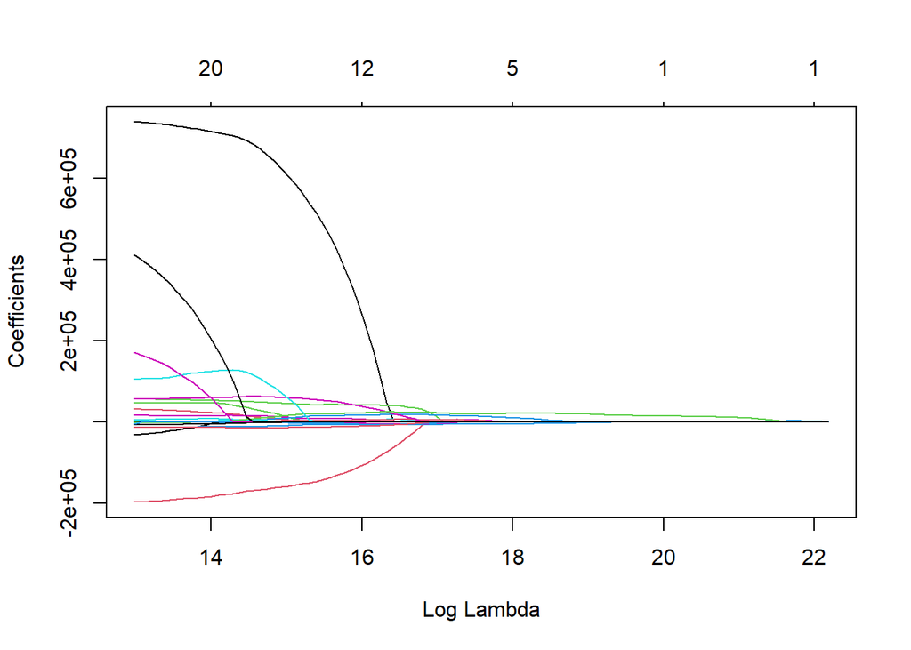

```r
plot(lasso.mod, 'lambda')
```

**Gráfico de coeficientes en función de la norma de penalización**

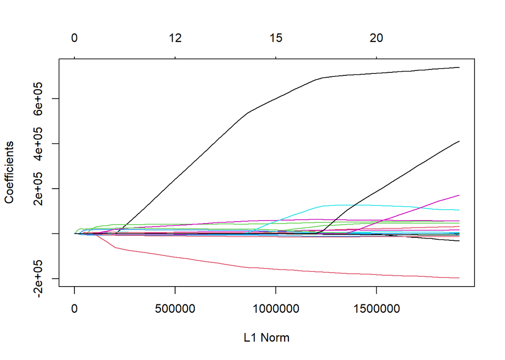

```r
plot(lasso.mod)
```

¿Qué muestra cada uno de estos gráficos?

Podemos realizar los gráficos para los valores de lambda también con ggplot.

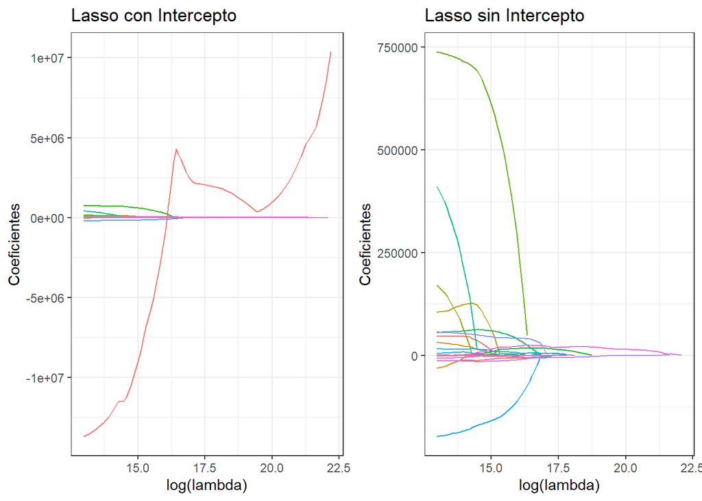

```r
# Gráfico de coeficientes en función del lambda con intercepto
g1 = lasso_coef  %>%
  ggplot(., aes(log(lambda), estimate, group=term, color=term)) +
  geom_line() +
  theme_bw()  +
  theme(legend.position = 'none') +
  labs(title="Lasso con Intercepto",  y="Coeficientes")
# Gráfico de coeficientes en función del lambda sin intercepto
g2 = lasso_coef %>%
  filter(term!='(Intercept)') %>%
  ggplot(., aes(log(lambda), estimate, group=term, color=term)) +
  geom_line() +
  theme_bw()  +
  theme(legend.position = 'none') +
  labs(title="Lasso sin Intercepto", y="Coeficientes")
# armamos la grilla con ambos gráficos
plot_grid(g1,g2)
```

Veamos un poco mejor aquellas variables que sobreviven para mayores valores de lambda ¿Qué tienen en común todas estas variables?

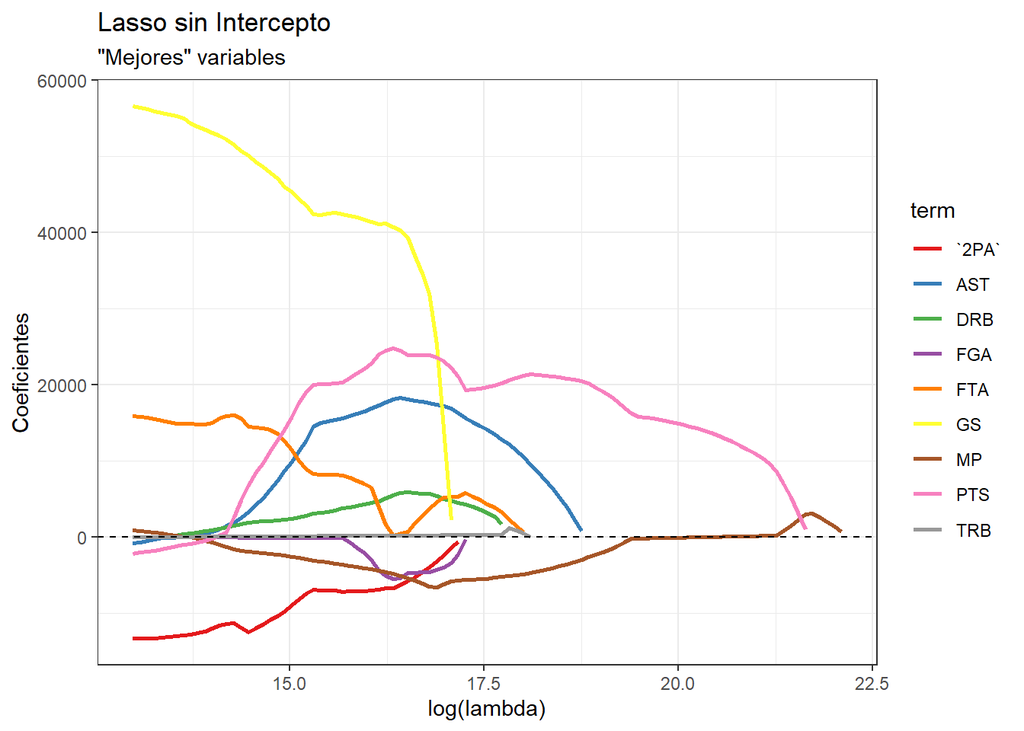

```r
# Seleccionamos los terminos que sobreviven para valores altos de lambda
terminos_sobrevientes = lasso_coef %>%
  filter(log(lambda)>17, term != "(Intercept)") %>%
  select(term) %>%
  distinct() %>%
  pull()
# Graficamos
lasso_coef %>% filter(term %in% terminos_sobrevientes) %>%
  ggplot(., aes(log(lambda), estimate, group=term, color=term)) +
  geom_line(size=1) +
  geom_hline(yintercept = 0, linetype='dashed') +
  theme_bw() +
  labs(title="Lasso sin Intercepto", y="Coeficientes", subtitle= "\"Mejores\" variables") +
  scale_color_brewer(palette = 'Set1')
```

Vemos que las variables que “sobreviven” para mayores valores de lambda son las que están medidas con una escala mayor.

## Estandarización en `glmnet`

Existen dos maneras de estandarizar las variables en `glmnet`.

1. Setear `standardize = TRUE`. **standardize** es un flag lógico para estandarizar las variables. Con esto se estandariza las regresoras y los coeficientes estimados están en la escala original de la variable.
2. Pasar los conjuntos de datos estandarizados.

## Lasso estandarizado

Replicamos todo el análisis previo pero para los datos estandarizados.

```r
# Modelo lasso
lasso.mod = glmnet(x = nba_mtx, # Matriz de regresores
                   y = nba_salary, #Vector de la variable a predecir
                   alpha = 1, # Indicador del tipo de regularizacion
                   standardize = TRUE) # Estandarizamos
# aplicamos la función tidy para obtener los coeficientes del modelo
lasso_coef = lasso.mod %>% tidy() %>% arrange(step)
lasso_coef
```

| term | step | estimate | lambda | dev.ratio |
| --- | --- | --- | --- | --- |
| (Intercept) | 1 | 1.036857e+07 | 7841387.708 | 0.00000000 |
| (Intercept) | 2 | 9.438700e+06 | 7144780.435 | 0.08940008 |
| PTS | 2 | 1.393643e+03 | 7144780.435 | 0.08940008 |
| VORP | 2 | 6.251869e+04 | 7144780.435 | 0.08940008 |
| (Intercept) | 3 | 8.724132e+06 | 6510057.833 | 0.17192802 |
| FT | 3 | 4.170216e+02 | 6510057.833 | 0.17192802 |
| PTS | 3 | 2.123262e+03 | 6510057.833 | 0.17192802 |
| VORP | 3 | 3.192408e+05 | 6510057.833 | 0.17192802 |
| (Intercept) | 4 | 8.095641e+06 | 5931722.238 | 0.24145037 |
| FT | 4 | 2.302735e+03 | 5931722.238 | 0.24145037 |

[output cut: 2186 more lines]

### Gráficos de análisis

**Gráfico de coeficientes en función del lambda**

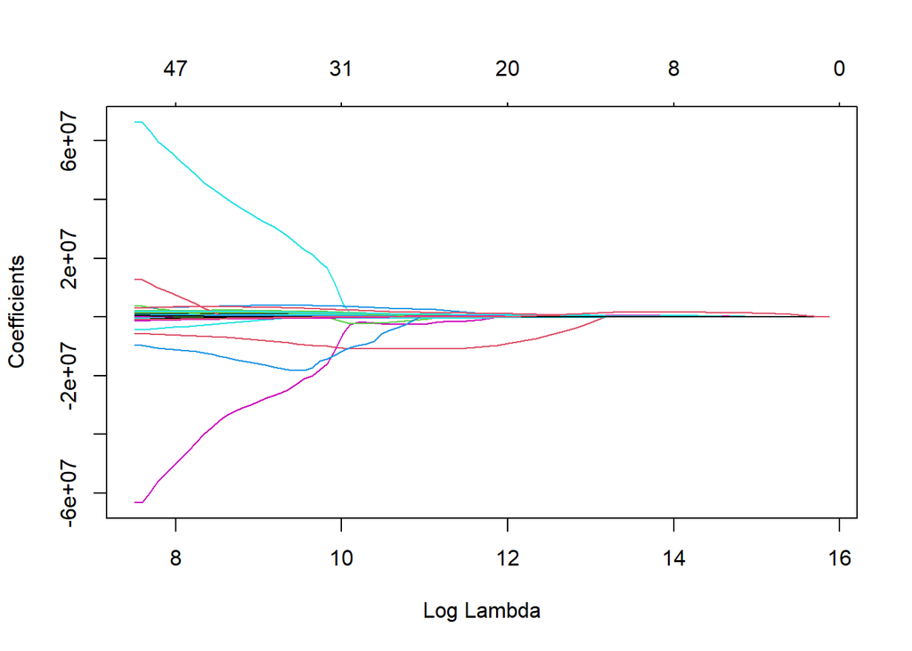

```r
plot(lasso.mod, 'lambda')
```

**Gráfico de coeficientes en función de la norma de penalización**

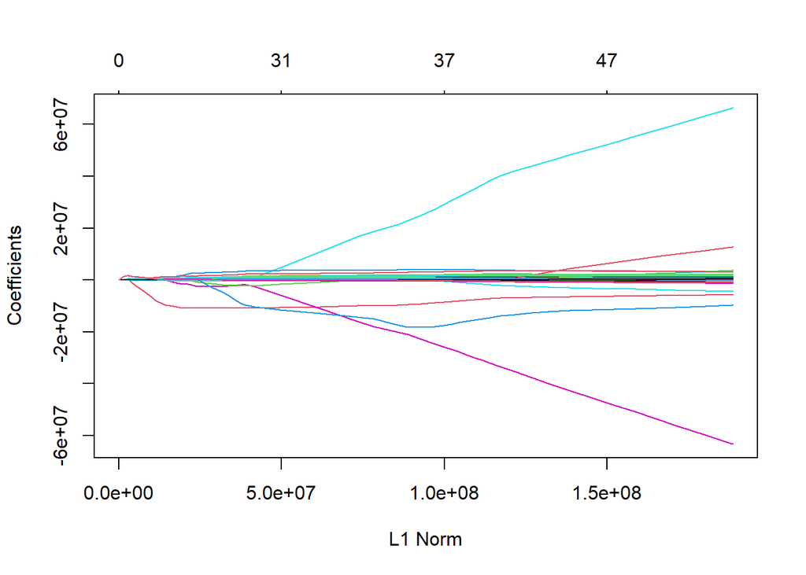

```r
plot(lasso.mod)
```

**Con ggplot**

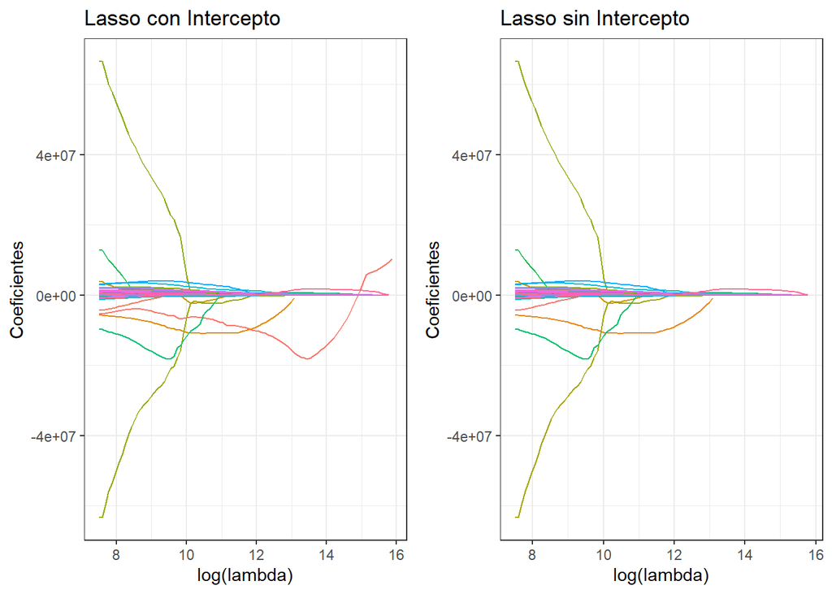

```r
# Gráfico de coeficientes en función del lambda con intercepto
g1 = lasso_coef %>%
  ggplot(., aes(log(lambda), estimate, group=term, color=term)) +
  geom_line() +
  theme_bw()  +
  theme(legend.position = 'none') +
  labs(title="Lasso con Intercepto",  y="Coeficientes")
# Gráfico de coeficientes en función del lambda sin intercepto
g2=lasso_coef %>%
  filter(term!='(Intercept)') %>%
  ggplot(., aes(log(lambda), estimate, group=term, color=term)) +
  geom_line() +
  theme_bw()  +
  theme(legend.position = 'none') +
  labs(title="Lasso sin Intercepto", y ="Coeficientes")
# armamos la grilla con ambos gráficos
plot_grid(g1,g2)
```

Veamos ahora cuáles variables sobreviven para mayores valores de lambda.

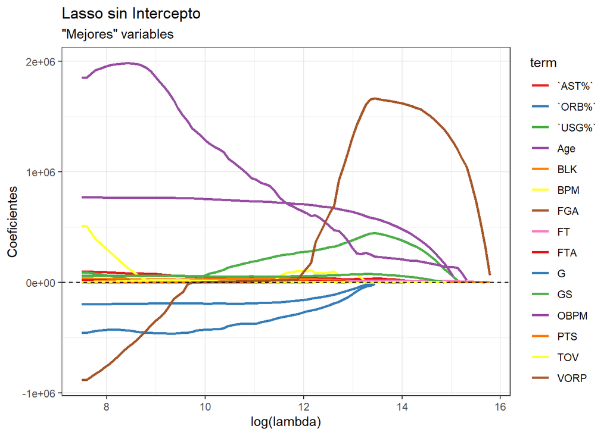

```r
# Seleccionamos los terminos que sobreviven para valores altos de lambda
terminos_sobrevientes = lasso_coef %>%
  filter(log(lambda)>13.1, term != "(Intercept)") %>%
  select(term) %>%
  distinct() %>%
  pull()
# Graficamos
lasso_coef %>%
  filter(term %in% terminos_sobrevientes) %>%
  ggplot(., aes(log(lambda), estimate, group=term, color=term)) +
  geom_line(size=1)  +
  scale_colour_manual(values=rep(brewer.pal(8,"Set1"),times=2))+
#   scale_color_brewer(palette = mycolors) +
  geom_hline(yintercept = 0, linetype='dashed') +
  theme_bw() +
  labs(title="Lasso sin Intercepto", y="Coeficientes", subtitle= "\"Mejores\" variables")
```

Observamos que ahora tenemos otro set de “mejores” variables.

¿Podemos decidir cuál es el valor óptimo de lambda?

### Elección del lambda óptimo

Para elegir el valor óptimo de lambda, lo común es realizar cross-validation. La función `cv.glmnet` nos permite realizar esto de manera sencilla.

Al igual que para la función `glmnet` cuenta con los parámetros **x**, **y**, **alpha** y **standardize**, incluyendo un nuevo parámetro:

- **type.measure**: función de pérdida/error que se va a utilizar en CV. Para los modelos de regularización el **default es MSE**.

**Salida Base**

```r
lasso_cv = cv.glmnet(x = nba_mtx,
                     y = nba_salary,
                     alpha = 1,
                     standardize = T)
summary(lasso_cv)
```

```
##            Length Class  Mode
## lambda     91     -none- numeric
## cvm        91     -none- numeric
## cvsd       91     -none- numeric
## cvup       91     -none- numeric
## cvlo       91     -none- numeric
## nzero      91     -none- numeric
## call        5     -none- call
## name        1     -none- character
## glmnet.fit 12     elnet  list
## lambda.min  1     -none- numeric
## lambda.1se  1     -none- numeric
## index       2     -none- numeric
```

Brinda mucha información:

- *lambda*: valor de lambda
- *cvm* (Cross-validation mean): es la media del MSE (error)
- *cvsd* (Cross-validation Standard Error): desvio estandar del MSE (error)
- *cvup* y *cvlo*: Limite superior e inferior
- *nzero*: Coeficientes distintos de cero
- *lambda.min*: lambda para el cual el MSE (error) es mínimo
- *lambda.1se*: lambda que se encuentra a 1 desvío estandar del lambda.min
- *glm.fit*: incluye cantidad de variables, el valor de lambda y el porcentaje de deviance explicada por el modelo.

Si imprimimos el objeto tenemos:

```r
lasso_cv
```

```
##
## Call:  cv.glmnet(x = nba_mtx, y = nba_salary, alpha = 1, standardize = T)
##
## Measure: Mean-Squared Error
##
##     Lambda Index   Measure        SE Nonzero
## min 143555    44 3.716e+13 3.754e+12      22
## 1se 840806    25 4.090e+13 3.346e+12       8
```

**Gráfico Base**

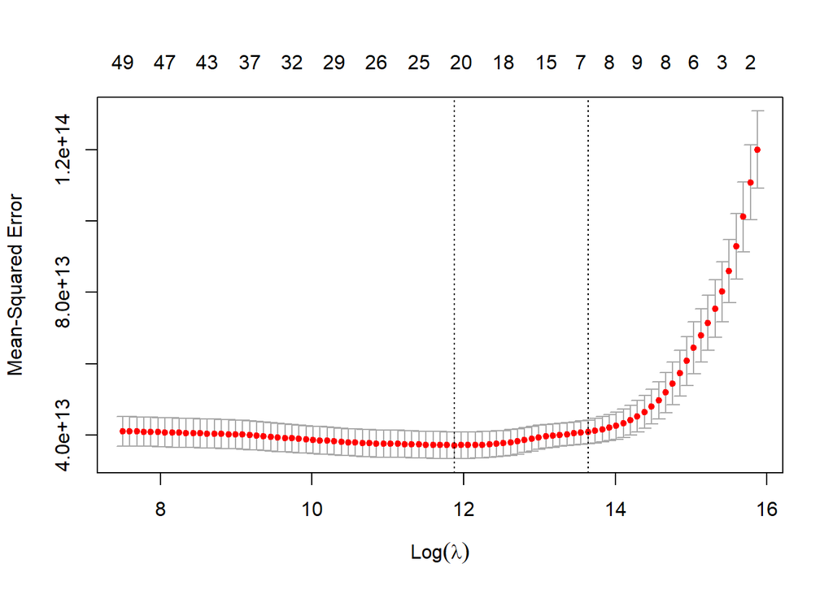

```r
plot(lasso_cv)
```

El gráfico nos muestra la media del MSE con su límite superior e inferior y la cantidad de variables que sobreviven para cada valor de lambda.

**Usando Broom**

Obtenemos la información del objeto **lasso_cv** con las funciones `tidy` y `glance`.

```r
# Información de CV en dataframe con tidy
lasso_cv %>% tidy()
```

| lambda | estimate | std.error | conf.low | conf.high | nzero |
| --- | --- | --- | --- | --- | --- |
| 7841387.708 | 1.200145e+14 | 1.079354e+13 | 1.092209e+14 | 1.308080e+14 | 0 |
| 7144780.435 | 1.108332e+14 | 1.045346e+13 | 1.003797e+14 | 1.212866e+14 | 2 |
| 6510057.833 | 1.011624e+14 | 9.787858e+12 | 9.137452e+13 | 1.109502e+14 | 3 |
| 5931722.238 | 9.289395e+13 | 9.258090e+12 | 8.363586e+13 | 1.021520e+14 | 3 |
| 5404764.383 | 8.598540e+13 | 8.816127e+12 | 7.716927e+13 | 9.480152e+13 | 3 |
| 4924620.011 | 8.022900e+13 | 8.418686e+12 | 7.181031e+13 | 8.864768e+13 | 3 |
| 4487130.342 | 7.545813e+13 | 8.054896e+12 | 6.740324e+13 | 8.351303e+13 | 4 |
| 4088506.050 | 7.148256e+13 | 7.731065e+12 | 6.375149e+13 | 7.921362e+13 | 4 |
| 3725294.441 | 6.798824e+13 | 7.486407e+12 | 6.050183e+13 | 7.547464e+13 | 5 |
| 3394349.550 | 6.448179e+13 | 7.258425e+12 | 5.722337e+13 | 7.174022e+13 | 6 |

[output cut: 81 more lines]

```r
# Lambda minimo y lambda a 1 desvio estandar
lasso_cv %>% glance()
```

| lambda.min | lambda.1se | nobs |
| --- | --- | --- |
| 143555.3 | 840806.3 | 282 |

Seleccionamos el lambda óptimo para crear el modelo final.

```r
# Selección lambda óptimo
lasso_lambda_opt = lasso_cv$lambda.min
# Entrenamiento modelo óptimo
lasso_opt = glmnet(x = nba_mtx, # Matriz de regresores
                   y = nba_salary, # Vector de la variable a predecir
                   alpha = 1, # Indicador del tipo de regularizacion
                   standardize = TRUE, # Estandarizamos
                   lambda = lasso_lambda_opt)
# Salida estandar
lasso_opt
```

```
##
## Call:  glmnet(x = nba_mtx, y = nba_salary, alpha = 1, lambda = lasso_lambda_opt,      standardize = TRUE)
##
##   Df  %Dev Lambda
## 1 21 75.21 143600
```

```r
# Tidy
lasso_opt %>% tidy()
```

| term | step | estimate | lambda | dev.ratio |
| --- | --- | --- | --- | --- |
| (Intercept) | 1 | -9640567.4164 | 143555.3 | 0.7521088 |
| PosPF | 1 | 288609.1329 | 143555.3 | 0.7521088 |
| PosSF | 1 | 289410.0192 | 143555.3 | 0.7521088 |
| Age | 1 | 710275.6559 | 143555.3 | 0.7521088 |
| G | 1 | -166983.3021 | 143555.3 | 0.7521088 |
| GS | 1 | 54288.9407 | 143555.3 | 0.7521088 |
| `3PA` | 1 | 3447.8201 | 143555.3 | 0.7521088 |
| `3P%` | 1 | -9601598.5293 | 143555.3 | 0.7521088 |
| `eFG%` | 1 | -307882.3992 | 143555.3 | 0.7521088 |
| FT | 1 | 231.2568 | 143555.3 | 0.7521088 |

[output cut: 12 more lines]

```r
# Glance (no es muy informativo)
lasso_opt %>% glance()
```

| nulldev | npasses | nobs |
| --- | --- | --- |
| 3.394609e+16 | 340 | 282 |

Han quedado 21 variables y el modelo explica el 75,2% de la deviance.

## Ridge

En este caso vamos a trabajar con $\alpha=0$. Vamos a replicar lo que ya realizamos para Lasso.

1. ¿Cuál es la penalización que introduce el modelo Ridge? $\sum_{j}\beta_j^2$
2. ¿Cómo impacta esto en las variables? Veamos nuevamente con un ejemplo.

En este caso, ya seteamos parámetro para estandarizar las variables. Si no lo fijásemos, el default sería de igual modo `standarize = TRUE`.

```r
#Modelo ridge
ridge.mod = glmnet(x = nba_mtx, # Matriz de regresores
                   y = nba_salary, #Vector de la variable a predecir
                   alpha = 0, # Indicador del tipo de regularizacion
                   standardize = TRUE)
#Coeficientes tidy
ridge_coef= ridge.mod %>% tidy() %>% arrange(step)
ridge_coef
```

| term | step | estimate | lambda | dev.ratio |
| --- | --- | --- | --- | --- |
| (Intercept) | 1 | 1.036857e+07 | 7841387707.5 | 2.088135e-35 |
| PosPF | 1 | 1.305772e-30 | 7841387707.5 | 2.088135e-35 |
| PosPG | 1 | 6.122821e-30 | 7841387707.5 | 2.088135e-35 |
| PosSF | 1 | -2.713366e-30 | 7841387707.5 | 2.088135e-35 |
| PosSG | 1 | -2.969098e-30 | 7841387707.5 | 2.088135e-35 |
| Age | 1 | 1.102511e-30 | 7841387707.5 | 2.088135e-35 |
| G | 1 | 1.409806e-31 | 7841387707.5 | 2.088135e-35 |
| GS | 1 | 2.493616e-31 | 7841387707.5 | 2.088135e-35 |
| MP | 1 | 8.440254e-33 | 7841387707.5 | 2.088135e-35 |
| FG | 1 | 4.766093e-32 | 7841387707.5 | 2.088135e-35 |

[output cut: 5090 more lines]

¿Qué ven de distinto en los coeficientes estimados del modelo respecto a Lasso?

### Gráficos de análisis

**Gráfico de coeficientes en función del lambda**

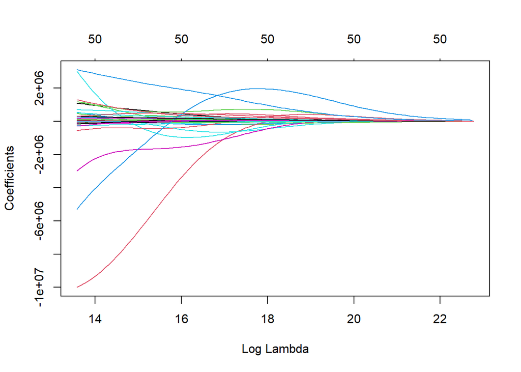

```r
plot(ridge.mod, 'lambda')
```

¿Qué ven de distinto en este gráfico respecto al que obtuvimos con la regresión Lasso?

**Gráfico de coeficientes en función de la norma de penalización**

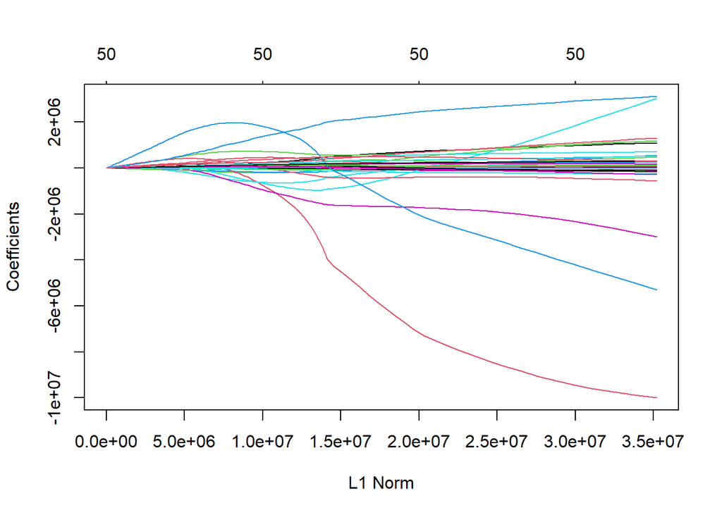

```r
plot(ridge.mod)
```

#### Gráficos de análisis con GGplot

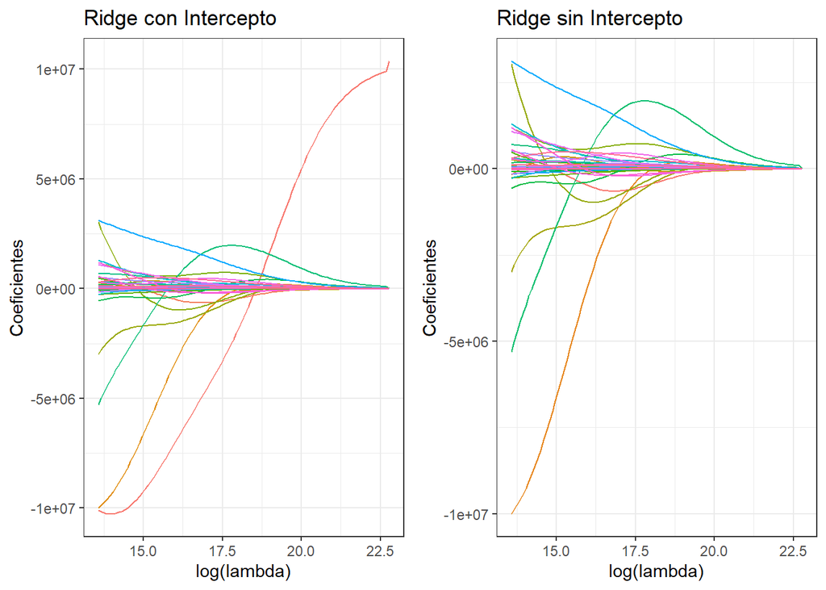

```r
# Gráfico de coeficientes en función del lambda con intercepto
g1 = ridge_coef %>%
  ggplot(., aes(log(lambda), estimate, group=term, color=term)) +
  geom_line() +
  theme_bw()  +
  theme(legend.position = 'none') +
  labs(title = "Ridge con Intercepto",  y="Coeficientes")
# Gráfico de coeficientes en función del lambda sin intercepto
g2 = ridge_coef %>%
  filter(term!='(Intercept)') %>%
  ggplot(., aes(log(lambda), estimate, group=term, color=term)) +
  geom_line() + theme_bw() +
  theme(legend.position = 'none') +
  labs(title="Ridge sin Intercepto", y="Coeficientes")
# armamos la grilla para graficar ambos juntos
plot_grid(g1,g2)
```

### Elección del lambda óptimo

```r
#cross-validation
ridge_cv = cv.glmnet(x = nba_mtx,
                     y = nba_salary,
                     alpha = 0,
                     standardize = T)
```

**Gráfico Base**

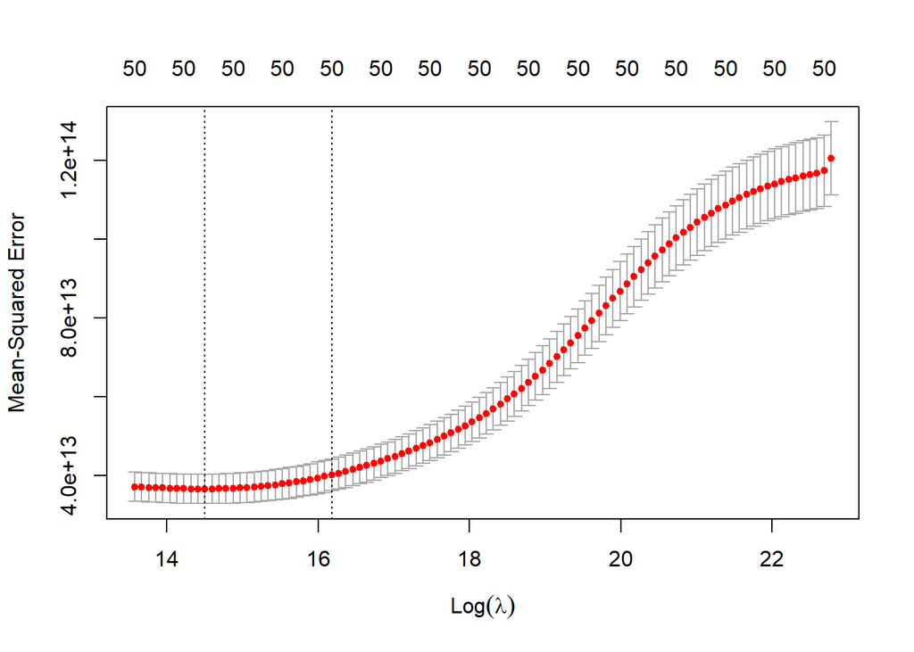

```r
plot(ridge_cv)
```

Seleccionamos el lambda óptimo para crear el modelo final.

```r
# Selección lambda óptimo
ridge_lambda_opt = ridge_cv$lambda.min
# Entrenamiento modelo óptimo
ridge_opt = glmnet(x = nba_mtx, # Matriz de regresores
                   y = nba_salary, #Vector de la variable a predecir
                   alpha = 0, # Indicador del tipo de regularizacion
                   standardize = TRUE,  # Estandarizamos
                   lambda = ridge_lambda_opt)
# Salida estandar
ridge_opt
```

```
##
## Call:  glmnet(x = nba_mtx, y = nba_salary, alpha = 0, lambda = ridge_lambda_opt,      standardize = TRUE)
##
##   Df %Dev  Lambda
## 1 50 74.7 1988000
```

```r
# Tidy
ridge_opt %>% tidy() %>% mutate(estimate = round(estimate, 4))
```

| term | step | estimate | lambda | dev.ratio |
| --- | --- | --- | --- | --- |
| (Intercept) | 1 | -9865196.8234 | 1988078 | 0.7470114 |
| PosPF | 1 | 832698.0703 | 1988078 | 0.7470114 |
| PosPG | 1 | 200366.8774 | 1988078 | 0.7470114 |
| PosSF | 1 | 693494.5656 | 1988078 | 0.7470114 |
| PosSG | 1 | 211411.3533 | 1988078 | 0.7470114 |
| Age | 1 | 619686.8132 | 1988078 | 0.7470114 |
| G | 1 | -113603.4782 | 1988078 | 0.7470114 |
| GS | 1 | 50424.7268 | 1988078 | 0.7470114 |
| MP | 1 | -96.6384 | 1988078 | 0.7470114 |
| FG | 1 | 3097.5356 | 1988078 | 0.7470114 |

[output cut: 41 more lines]

En este caso conserva todas las variables, obteniendo un porcentaje de deviance explicado muy similar a Lasso: 74,7%.

## Elastic Net

El modelo Elastic Net incorpora los dos tipos de penalización: Lasso (Norma L1) y Ridge (Norma L2). Define un compromiso entre las penalidades de lasso y ridge. El parámetro $\alpha$ regula la importancia de cada penalización, cuanto más cerca de cero será más importante la penalización del tipo Ridge y más cerca de 1, la tipo Lasso.

En este caso vamos a trabajar con $\alpha = 0.5$. Vamos a replicar lo que ya realizamos para Lasso y Ridge, individualmente.

```r
# Modelo elastic net
elastic.mod = glmnet(x = nba_mtx, # Matriz de regresores
                     y = nba_salary, #Vector de la variable a predecir
                     alpha = 0.5, # Indicador del tipo de regularizacion
                     standardize = TRUE)
# Coeficientes del modelo
elastic_coef = elastic.mod %>% tidy() %>% mutate(estimate = round(estimate, 4)) %>% arrange(step)
elastic_coef
```

| term | step | estimate | lambda | dev.ratio |
| --- | --- | --- | --- | --- |
| (Intercept) | 1 | 1.036857e+07 | 15682775.415 | 0.00000000 |
| (Intercept) | 2 | 9.746019e+06 | 14289560.871 | 0.07138937 |
| FG | 2 | 7.498770e+01 | 14289560.871 | 0.07138937 |
| FT | 2 | 1.383329e+03 | 14289560.871 | 0.07138937 |
| PTS | 2 | 6.015848e+02 | 14289560.871 | 0.07138937 |
| VORP | 2 | 1.066455e+05 | 14289560.871 | 0.07138937 |
| (Intercept) | 3 | 9.073057e+06 | 13020115.667 | 0.14605058 |
| FG | 3 | 7.883338e+02 | 13020115.667 | 0.14605058 |
| FT | 3 | 2.619886e+03 | 13020115.667 | 0.14605058 |
| FTA | 3 | 7.379211e+02 | 13020115.667 | 0.14605058 |

[output cut: 2472 more lines]

¿Qué ven de distinto en los coeficientes estimados del modelo respecto a Lasso y Ridge?

### Gráficos de análisis

**Gráfico de coeficientes en función del lambda**

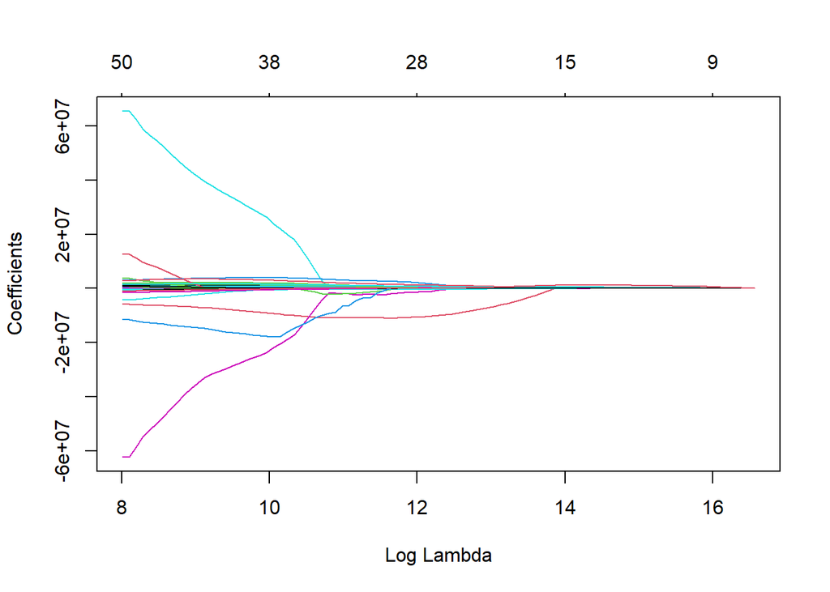

```r
plot(elastic.mod, 'lambda')
```

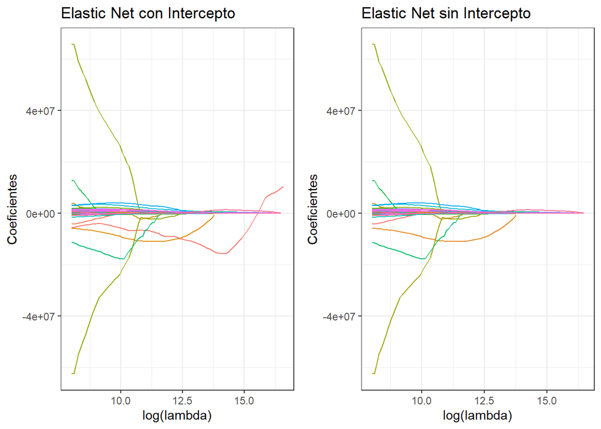

```r
# Gráfico de coeficientes en función del lambda con intercepto
g1 = elastic_coef  %>%
  ggplot(., aes(log(lambda), estimate, group=term, color=term)) +
  geom_line() +
  theme_bw()  +
  theme(legend.position = 'none') +
  labs(title="Elastic Net con Intercepto",  y="Coeficientes")
# Gráfico de coeficientes en función del lambda sin intercepto
g2 = elastic_coef %>%
  filter(term!='(Intercept)') %>%
  ggplot(., aes(log(lambda), estimate, group=term, color=term)) +
  geom_line() +
  theme_bw()  +
  theme(legend.position = 'none') +
  labs(title="Elastic Net sin Intercepto", y="Coeficientes")
# armamos grilla para graficar ambos juntos
plot_grid(g1,g2)
```

### Elección del lambda óptimo

```r
elastic_cv = cv.glmnet(x = nba_mtx,
                       y = nba_salary,
                       alpha = 0.5,
                       standardize = T)
```

**Grafico Base**

Presten especial atención al eje superior ¿Qué está sucediendo?

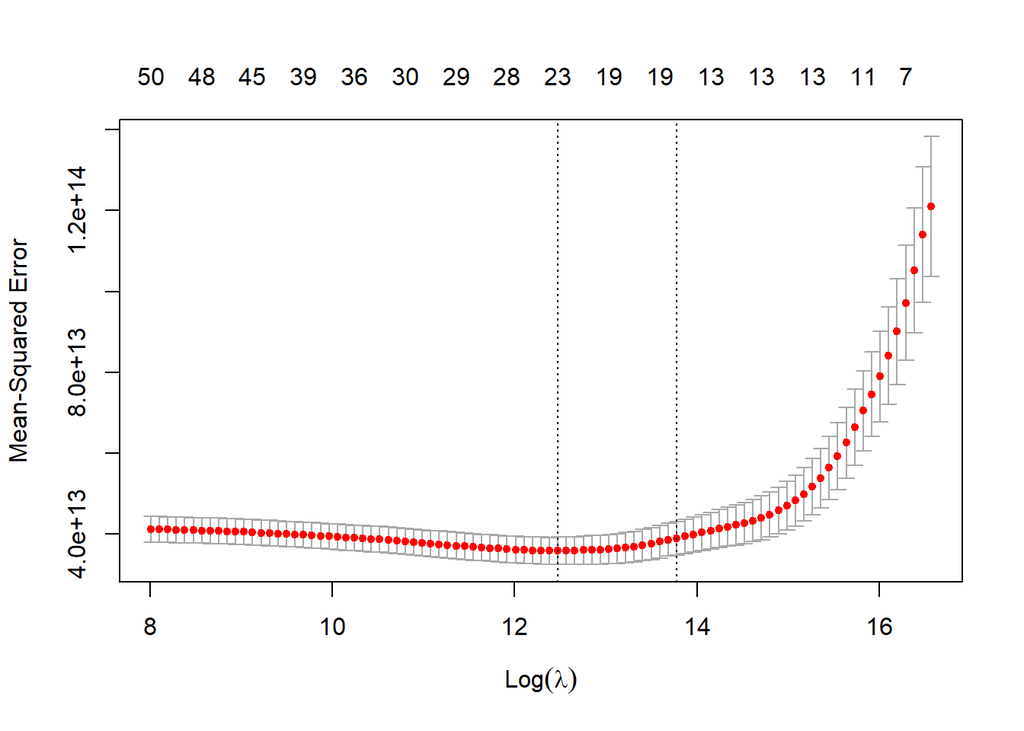

```r
plot(elastic_cv)
```

Seleccionamos el lambda óptimo para crear el modelo final.

```r
# Selección lambda óptimo
elastic_lambda_opt = elastic_cv$lambda.min
# Entrenamiento modelo óptimo
elastic_opt = glmnet(x = nba_mtx, # Matriz de regresores
                     y = nba_salary, #Vector de la variable a predecir
                     alpha = 0.5, # Indicador del tipo de regularizacion
                     standardize = TRUE,  # Estandarizamos
                     lambda = elastic_lambda_opt)
# Salida estandar
elastic_opt
```

```
##
## Call:  glmnet(x = nba_mtx, y = nba_salary, alpha = 0.5, lambda = elastic_lambda_opt,      standardize = TRUE)
##
##   Df  %Dev Lambda
## 1 23 75.17 261600
```

```r
# Tidy
elastic_opt %>%  tidy()  %>% mutate(estimate = round(estimate, 4))
```

| term | step | estimate | lambda | dev.ratio |
| --- | --- | --- | --- | --- |
| (Intercept) | 1 | -1.005522e+07 | 261604.5 | 0.7516643 |
| PosPF | 1 | 3.182684e+05 | 261604.5 | 0.7516643 |
| PosSF | 1 | 3.180008e+05 | 261604.5 | 0.7516643 |
| Age | 1 | 7.040630e+05 | 261604.5 | 0.7516643 |
| G | 1 | -1.612721e+05 | 261604.5 | 0.7516643 |
| GS | 1 | 5.556471e+04 | 261604.5 | 0.7516643 |
| FG | 1 | 4.649068e+03 | 261604.5 | 0.7516643 |
| FGA | 1 | 1.380717e+03 | 261604.5 | 0.7516643 |
| `3PA` | 1 | 4.814618e+03 | 261604.5 | 0.7516643 |
| `3P%` | 1 | -9.343285e+06 | 261604.5 | 0.7516643 |

[output cut: 14 more lines]

## Breve comparación entre modelos

Vamos a comparar la relación entre el porcentaje de deviance explicada y lambda para los tres tipos de modelos que realizamos.

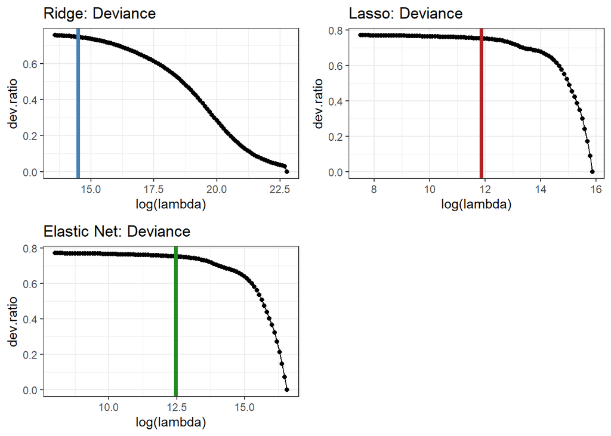

```r
ridge_dev = ridge_coef %>%
  select(lambda, dev.ratio) %>% distinct() %>%
  ggplot(., aes(log(lambda), dev.ratio)) +
  geom_point() +
  geom_line() +
  geom_vline(xintercept = log(ridge_lambda_opt), color='steelblue', size=1.5) +
  labs(title='Ridge: Deviance') +
  theme_bw()
lasso_dev = lasso_coef %>% select(lambda, dev.ratio) %>% distinct() %>%
  ggplot(., aes(log(lambda), dev.ratio)) +
  geom_point() +
  geom_line() +
  geom_vline(xintercept = log(lasso_lambda_opt), color='firebrick', size=1.5) +
  labs(title='Lasso: Deviance') +
  theme_bw()
elastic_dev = elastic_coef %>% select(lambda, dev.ratio) %>% distinct() %>%
  ggplot(., aes(log(lambda), dev.ratio)) +
  geom_point() +
  geom_line() +
  geom_vline(xintercept = log(elastic_lambda_opt), color='forestgreen', size=1.5) +
  labs(title='Elastic Net: Deviance') +
  theme_bw()
plot_grid(ridge_dev, lasso_dev, elastic_dev)
```

## Testing

Con los modelos óptimos que encontramos se puede calcular cuál es el RMSE en los datasets de training y testing, para decidir cuál es el modelo que minimiza el error en las predicciones.

```r
# Definimos una función augment que funcione con glmnet
augment_glmnet = function(df, y, model) {
  # formula del modelo
  formula = as.formula(str_c(y, "~."))
  # Matriz con los regresores
  data_matrix = model.matrix(formula, data = df)
  # predicciones
  predictions = predict(model, data_matrix)
  pred_colname = str_c(y, "predicho", sep = "_")
  df[pred_colname] = predictions
  return(df)
}
```

Vamos a agregar dos modelos para comparar: el salario promedio del set de entrenamiento y el modelo lineal múltiple clásico.

```r
# Salario promedio del set de entrenamiento
salario_promedio = mean(train$salario)
# Modelo lineal
modelo_lineal = lm(salario~., data = train)
```

Realizamos las predicciones ambos modelos.

```r
# Salario promedio
prediccion_modelo_nulo = tibble(salario = train$salario, salario_predicho = salario_promedio)
# Predicciones del modelo lineal
prediccion_modelo_lineal = augment(modelo_lineal) %>% mutate(salario_predicho = .fitted) %>% select(salario, salario_predicho)
```

Realizamos las predicciones de los modelos de glmnet.

```r
# Lista de modelos
modelos_glmnet = list(lasso = lasso_opt, ridge = ridge_opt, elastic = elastic_opt)
# Predicciones de los modelos glmnet
lista_predicciones_training = map(.x = modelos_glmnet,
                                  .f = augment_glmnet,
                                  df = train,
                                  y = "salario")
# Agregamos las otras predicciones a la lista
lista_predicciones_training = lista_predicciones_training %>%
  prepend(list(nulo = prediccion_modelo_nulo, lineal = prediccion_modelo_lineal))
```

Obtenemos el RMSE para el set de **entrenamiento**.

```r
map_dfr(.x = lista_predicciones_training,
        .f = rmse,
        truth = "salario",
        estimate = "salario_predicho",
        .id = "modelo")
```

| modelo | .metric | .estimator | .estimate |
| --- | --- | --- | --- |
| nulo | rmse | standard | 10971609 |
| lineal | rmse | standard | 5243305 |
| lasso | rmse | standard | 5462618 |
| ridge | rmse | standard | 5518497 |
| elastic | rmse | standard | 5467514 |

¿Cuál es el modelo que realiza la mejor predicción? ¿Qué esperan que suceda con el RMSE en el set de **evaluación**?

Obtenemos el RMSE para los modelos en el set de **evaluación**

```r
# Predicción del promedio
prediccion_modelo_nulo = tibble(salario = test$salario, salario_predicho = salario_promedio)
# Predicción modelo lineal
prediccion_modelo_lineal = augment(modelo_lineal, newdata = test) %>%
  mutate(salario_predicho = .fitted)
# Predicciones glmnet
lista_predicciones_test = map(.x = modelos_glmnet,
                              .f = augment_glmnet,
                              df = test,
                              y = "salario")
# Lista completa de predicciones
lista_predicciones_test = lista_predicciones_test %>% prepend(list(nulo=prediccion_modelo_nulo, lineal = prediccion_modelo_lineal))
# RMSE en el set de evaluación
map_dfr(lista_predicciones_test,
        rmse,
        truth = "salario",
        estimate = "salario_predicho",
        .id = "modelo")
```

| modelo | .metric | .estimator | .estimate |
| --- | --- | --- | --- |
| nulo | rmse | standard | 10010977 |
| lineal | rmse | standard | 6716828 |
| lasso | rmse | standard | 6332744 |
| ridge | rmse | standard | 6400693 |
| elastic | rmse | standard | 6342068 |

¿Cuál es el modelo de mejor performance en el set de evaluación? ¿Qué sucedió con el modelo de regresión clásico?